# WWTest

David Epstein

12/13/2017

## Read in Data

Input the training and test sets, then combine them into one big data set for exploratory analysis.

## Exploratory Data Analysius

I look at the distributions of the variables, both in the training and test sets. They should be close to each other to ensure consistency in estimation. And for factor variables the levels should be the same in each data set. I would also be suspicious if the modal level of a factor variable were NA.

Of course I don’t know what the substantive interpretations of the variables are, and I am time constrained, so for this analysis I will let these issues pass.

### Categorical Variables

First we do the categorical variables. They all seem to be legitimate factors, so they will be treated as such. (Unordered factors are the safest approach here. With more time and substantive knowledge I would probably treat some of them as ordered factors.)

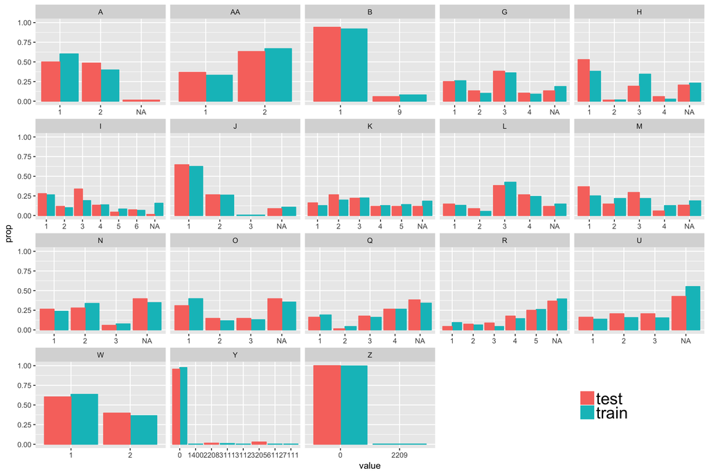

### Continuous Variables

Now we examine the continuous variables. All distributions overlap satisfactorily.

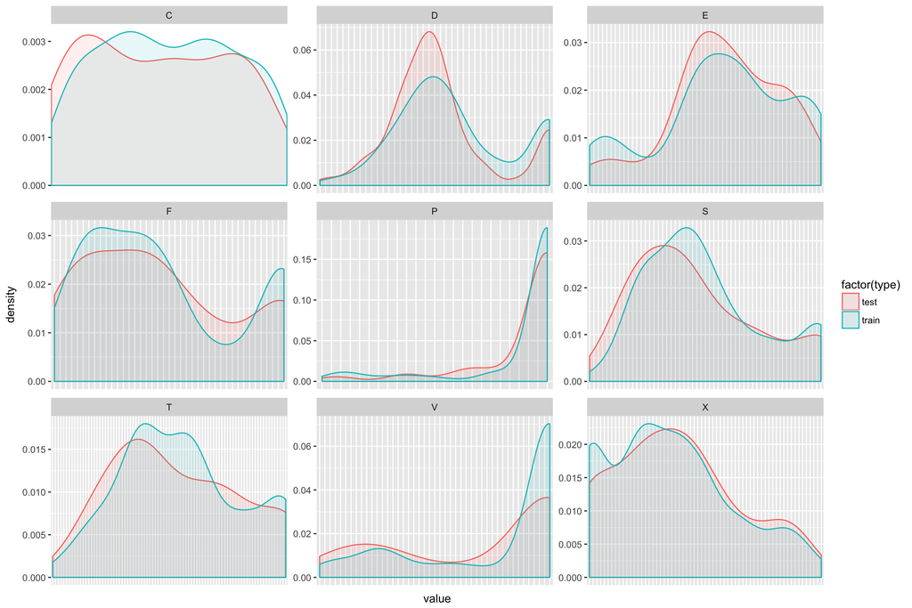

```r
all_data %>% gather('variable','value',1:27)  %>%
  filter(!variable %in% factorVars) %>%
  ggplot(aes(x=value,group=type, color=factor(type),fill=factor(type))) +
  geom_density(alpha=0.1) +
  facet_wrap(~variable, scales=c('free')) +
  theme(axis.text.x=element_blank(),
        axis.ticks.x=element_blank())
```

## Models

Boldly on to the modeling. We have a binary dependent variable, so I will run one treew-based model (random forest) and a regularized logit regression model. Large differences in the outputs of these models should be investigated.

### Imputation

The random forest models do not allow for missing values. For the categorical variables, I will count missing values as extra categories of the factor variable. For continuous variables, I do random imputation from the distribution of that variable, which does not interfere with the expected overall distribution of the variable.

```r
random.imp <- function (a){
  missing <- is.na(a)
  n.missing <- sum(missing)
  a.obs <- a[!missing]
  imputed <- a
  imputed[missing] <- sample (a.obs, n.missing, replace=TRUE)
  return (imputed)
}

all_data_imp <- all_data %>% mutate_at(factorVars,funs(fct_explicit_na)) %>%
  mutate_at(numericVars,funs(random.imp))

train_imp <- all_data_imp %>% filter(type=='train') %>% select(-type)
test_imp <- all_data_imp %>% filter(type=='test') %>% select(-type,-Outcome)
```

### Random Forest

We first run a random forest. Some parameter tuning led to a forest with 2000 trees, with 5 variables randomly selected at each node. As shown, the ensemble of trees has an out of bag error rate of just over 20%. We use the forest to create predictions for both the training variables and the test set.

```r
train.rf <- randomForest(Outcome ~ ., data=train_imp, ntree=2000, mtry=5, importance=TRUE)
train.rf
```

```
##
## Call:
##  randomForest(formula = Outcome ~ ., data = train_imp, ntree = 2000,      mtry = 5, importance = TRUE)
##                Type of random forest: classification
##                      Number of trees: 2000
## No. of variables tried at each split: 5
##
##         OOB estimate of  error rate: 21.07%
## Confusion matrix:
##    0   1 class.error
## 0 87  34   0.2809917
## 1 29 149   0.1629213
```

```r
pred.rf.train <- predict(train.rf,type = "prob")[,2]
pred.rf.test <-  predict(train.rf,type = "prob",test_imp)[,2]
```

Random forests also produce an estimate of the relative importance of each variable in determining the outcome. As shown here, variables S and X head the list in terms of importance. If we were to know the substantive meaning of these variables, we would do further investigations into the meaning of these patterns.

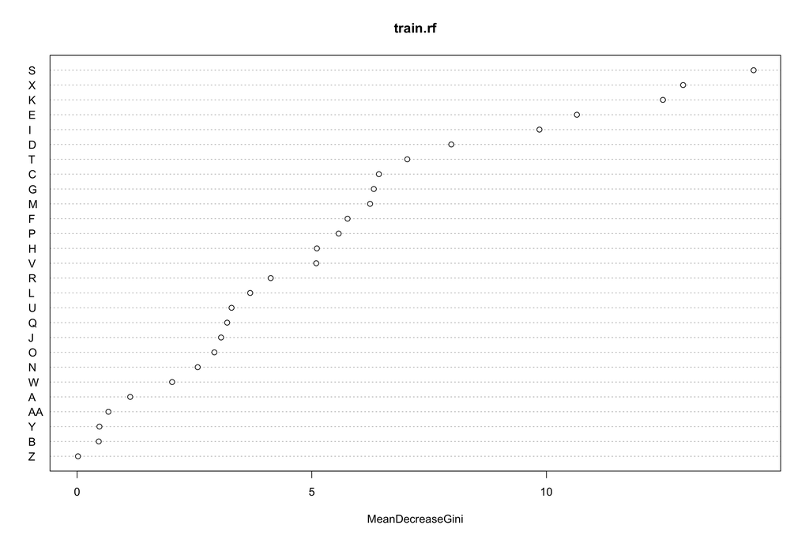

```r
varImpPlot(train.rf,type=2)
```

### Lasso

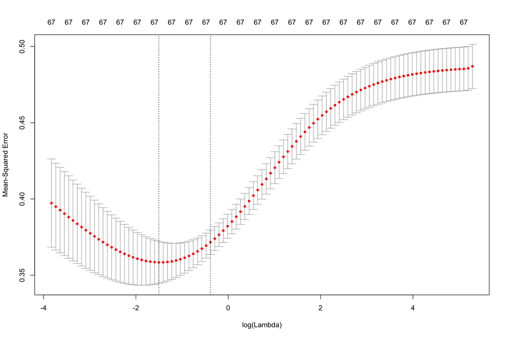

```r
x <- model.matrix(Outcome~.,train_imp)
y <- ifelse(train_imp$Outcome=='1',1,0)

cv.out <- cv.glmnet(x,y,alpha=0,family='binomial',type.measure = 'mse')

plot(cv.out)
```

```r
#min value of lambda
lambda_min <- cv.out$lambda.min
#best value of lambda
lambda_1se <- cv.out$lambda.1se
#regression coefficients
#coef(cv.out,s=lambda_1se)

print_glmnet_coefs <- function(cvfit, s="lambda.min") {
  ind <- which(coef(cvfit, s=s) != 0)
  df <- data.frame(
    feature=rownames(coef(cvfit, s=s))[ind],
    coeficient=coef(cvfit, s=s)[ind]
  )
  kable(df)
}

#print_glmnet_coefs(cv.out)


pred.lasso.train <- lasso_prob <- predict(cv.out,newx = x,s='lambda.1se',type='response')
pred.lasso.test  <- predict(cv.out,newx=model.matrix(~.,data=test_imp),s='lambda.1se',type='response')
```

## Combining Predictions

We have run separate random forest and lasso models. As a first check, we look at how similar their estimates of the probabilities are. The closer the set of points is to the 45-degree line, the more similar the model estimates. As shown, the estimates are in general close to each other. We can also note an overall clockwise rotation of the estimates relative to the 45-degree line. This shows that the predictions of the random forest are in general more extreme than the lasso – the high values are higher and the low values are lower than their counterparts.

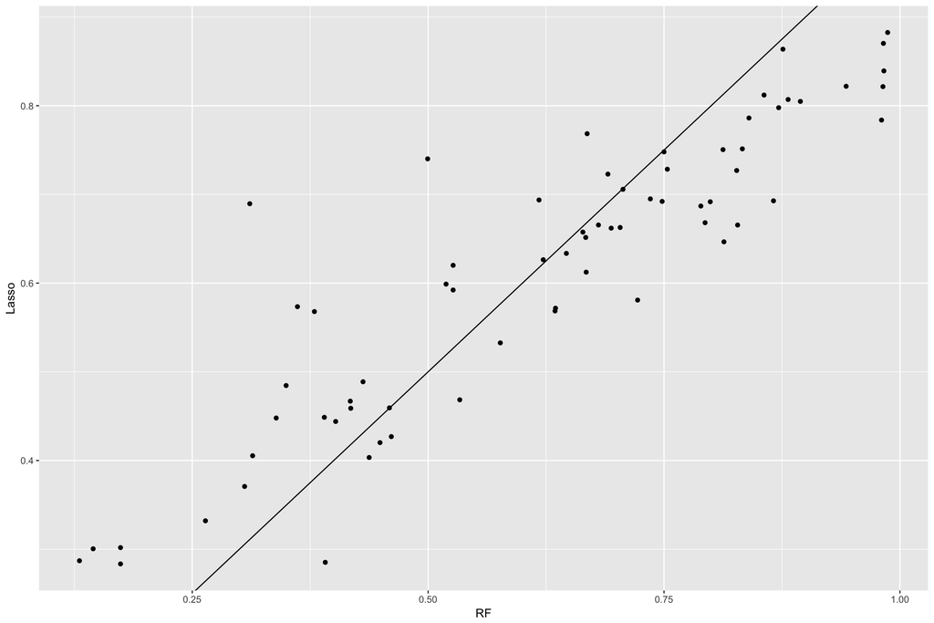

```r
preds <- cbind(pred.rf.test,pred.lasso.test) %>% as_tibble
colnames(preds) <- c('RF','Lasso')

preds %>% ggplot(aes(x=RF,y=Lasso)) + geom_point() + geom_abline(intercept = 0, slope=1)
```

Finally, we are now in a position to combine the estimates from the Lasso and random forest models. I use the simplest form of model stacking, which is to take the average of the probabilities from each model. These results are output in the accompanying csv file, Predictions.csv.

```r
preds %>% mutate(Avg=(RF+Lasso)/2) %>% kable
```

[output not shown]